# Interactions Three Ways: Observed, Partial, and Predicted (Pan et al., 2013)

Authors

Reinhold Kliegl

Jinger Pan

Published

2026-08-28

After working through this page you will be able to:

- distinguish three complementary views of a model term — the **observed** relationship, the **partial-effect** view (`remef` / `MixedModelsExtras.partial_fitted`), and the **predicted** (marginal) view (`Effects.jl`);
- read each of the significant interactions in `m09` off a consistent three-panel figure;
- explain *why* an interaction that is invisible in the raw data can be obvious in the partial-effect plot.

**NoteBefore you start**

**Prerequisite:** Eye–Voice Span in Rapid Automatized Naming — this page reuses its preferred model `m09` and its cached fit. Read that page first for the background, the data, and the model-building steps.

**Data used:** `pylsk13.rda` (`examples/eyevoicespan/`).

# 1 Why three panels?

Model `m09` from the companion page has four reliable interaction terms. Each one describes how the slope of one predictor changes with another, but a raw scatterplot rarely shows that directly: the other twelve terms in the model, the by-child random intercept, and the residual noise are all superimposed on it.

Three views pull the term apart:

| View | What it shows | How it is computed |
| --- | --- | --- |
| **Observed** | `log(RAN)` against the predictor, split by the moderator, with an ordinary least-squares line per group | nothing removed — the raw data |
| **Partial** | the same, after subtracting every model term *except* the target interaction and its lower-order relatives, and the random intercept | `partial_fitted(m09, keep; mode=:include) .+ residuals(m09)` — the Julia analogue of R’s `remef(..., keep=TRUE, grouping=TRUE, ran=NULL)` |
| **Predicted** | the model’s fitted mean on a regular grid, with a 95% confidence band, holding the other predictors at typical values | `Effects.effects(grid, m09; level=0.95)` |

The **observed** panel is honest about scatter but confounded. The **partial** panel keeps the residual scatter (so you can still judge influence and fit) while removing the confounds. The **predicted** panel removes the scatter too and adds proper inferential uncertainty, but it *averages over* the predictors that are not on the grid — so it can look weaker than the partial view when a moderator you have collapsed also interacts with the x-axis variable.

# 2 Setup

```julia
using AlgebraOfGraphics
using AlgebraOfGraphics: linear
using CairoMakie
using CategoricalArrays
using DataFrames
using Effects
using MixedModels
using MixedModelsExtras
using RData
using Statistics
using StatsBase

using SMLP2026: fit_or_restore

const progress = false
set_aog_theme!()
```

```julia
dat = DataFrame(load(joinpath(@__DIR__, "pylsk13.rda"))["dat"])
transform!(dat,
  :subj => (x -> categorical(string.("S", x))) => :Subj,
  :group => (x -> categorical(recode(x, 1 => "control", 2 => "dyslexic"))) => :Group,
  :condition => (x -> categorical(recode(x, 1 => "digit", 2 => "dice"))) => :Condition,
  :ran => ByRow(log) => :lran,
)
levels!(dat.Group, ["control", "dyslexic"])
levels!(dat.Condition, ["digit", "dice"])
dat.evs_c = dat.evs .- mean(dat.evs)
dat.gaze_c = dat.gaze .- mean(dat.gaze)

contrasts = Dict(
  :Condition => DummyCoding(; base="digit"),
  :Group => DummyCoding(; base="control"),
)
m09 = fit_or_restore("eyevoicespan_m09.json", MixedModel,
  @formula(lran ~ 1 + Condition + Group + evs_c + gaze_c +
    Condition & Group + Condition & evs_c + Condition & gaze_c +
    Group & evs_c + Group & gaze_c + evs_c & gaze_c +
    Condition & Group & evs_c + Condition & Group & gaze_c +
    (1 | Subj)),
  dat; contrasts, progress)
```

|  | Est. | SE | z | p | σ_Subj |
| --- | --- | --- | --- | --- | --- |
| (Intercept) | 2.9984 | 0.0683 | 43.88 | <1e-99 | 0.0982 |
| Condition: dice | 0.0770 | 0.0760 | 1.01 | 0.3108 |  |
| Group: dyslexic | 0.0117 | 0.0789 | 0.15 | 0.8825 |  |
| evs_c | -0.6308 | 0.1440 | -4.38 | <1e-04 |  |
| gaze_c | 0.0036 | 0.0009 | 4.17 | <1e-04 |  |
| Condition: dice & Group: dyslexic | 0.1299 | 0.0971 | 1.34 | 0.1807 |  |
| Condition: dice & evs_c | 0.6085 | 0.1998 | 3.05 | 0.0023 |  |
| Condition: dice & gaze_c | -0.0013 | 0.0009 | -1.41 | 0.1598 |  |
| Group: dyslexic & evs_c | 0.6163 | 0.1842 | 3.35 | 0.0008 |  |
| Group: dyslexic & gaze_c | -0.0020 | 0.0011 | -1.90 | 0.0569 |  |
| evs_c & gaze_c | -0.0051 | 0.0015 | -3.46 | 0.0006 |  |
| Condition: dice & Group: dyslexic & evs_c | -0.5512 | 0.2010 | -2.74 | 0.0061 |  |
| Condition: dice & Group: dyslexic & gaze_c | 0.0002 | 0.0011 | 0.18 | 0.8570 |  |
| Residual | 0.0861 |  |  |  |  |

The four interaction terms and their coefficients:

```julia
let
  targets = ["Condition: dice & evs_c", "Group: dyslexic & evs_c", "evs_c & gaze_c",
             "Condition: dice & Group: dyslexic & evs_c"]
  filter(:Name => in(targets), DataFrame(coeftable(m09)))
end
```

4×5 DataFrame

| Row | Name String | Coef. Float64 | Std. Error Float64 | z Float64 | Pr(>\|z\|) Float64 |
| --- | --- | --- | --- | --- | --- |
| 1 | Condition: dice & evs_c | 0.60853 | 0.199783 | 3.04595 | 0.00231946 |
| 2 | Group: dyslexic & evs_c | 0.616318 | 0.184165 | 3.34656 | 0.000818218 |
| 3 | evs_c & gaze_c | -0.00512145 | 0.0014823 | -3.45508 | 0.000550125 |
| 4 | Condition: dice & Group: dyslexic & evs_c | -0.551238 | 0.201037 | -2.74198 | 0.00610709 |

All four are reliable: `Condition & evs_c` (*p* ≈ .002), `Group & evs_c` (*p* ≈ .001), `evs_c & gaze_c` (*p* ≈ .001), and the three-way `Condition & Group & evs_c` (*p* ≈ .006).

# 3 Partial responses

`partial(keep)` returns the observed response with every term *not* in `keep` removed, plus the by-child random intercept removed — exactly what `remef(m09, fix = keep, keep = TRUE, grouping = TRUE, ran = NULL)` produces in R. `grouping = TRUE` means “also keep every lower-order term built from the same variables”, which here we spell out explicitly in each `keep` vector.

```julia
partial(keep) = partial_fitted(m09, keep, Dict(:Subj => String[]); mode=:include) .+ residuals(m09)

keep_C_evs   = ["(Intercept)", "Condition: dice", "evs_c", "Condition: dice & evs_c"]
keep_G_evs   = ["(Intercept)", "Group: dyslexic", "evs_c", "Group: dyslexic & evs_c"]
keep_evs_gz  = ["(Intercept)", "evs_c", "gaze_c", "evs_c & gaze_c"]
keep_CG_evs  = filter(c -> !occursin("gaze_c", c), coefnames(m09))   # everything without gaze

dp = select(dat, :Subj, :Condition, :Group, :evs, :gaze, :evs_c, :gaze_c, :lran)
dp.pf_C_evs   = partial(keep_C_evs)
dp.pf_G_evs   = partial(keep_G_evs)
dp.pf_evs_gz  = partial(keep_evs_gz)
dp.pf_CG_evs  = partial(keep_CG_evs)
dp.cg = categorical(string.(dp.Condition, " / ", dp.Group))

# tertiles of eye–voice span, for the EVS × Gaze figure
cut = quantile(dat.evs, [1/3, 2/3])
evsgrp(x) = x ≤ cut[1] ? "low" : x ≤ cut[2] ? "mid" : "high"
dp.evs_grp = categorical(evsgrp.(dp.evs); levels=["low", "mid", "high"])
tert_med = [median(dat.evs[evsgrp.(dat.evs) .== g]) for g in ["low", "mid", "high"]]
first(dp, 6)
```

6×14 DataFrame

| Row | Subj Cat… | Condition Cat… | Group Cat… | evs Float64 | gaze Int32 | evs_c Float64 | gaze_c Float64 | lran Float64 | pf_C_evs Float64 | pf_G_evs Float64 | pf_evs_gz Float64 | pf_CG_evs Float64 | cg Cat… | evs_grp Cat… |
| --- | --- | --- | --- | --- | --- | --- | --- | --- | --- | --- | --- | --- | --- | --- |
| 1 | S101 | digit | control | 1.33 | 242 | 0.458393 | -160.429 | 2.62394 | 2.81295 | 2.81295 | 2.61468 | 2.81295 | digit / control | high |
| 2 | S101 | dice | control | 0.97 | 397 | 0.0983929 | -5.42857 | 2.97604 | 2.97662 | 2.83973 | 2.82301 | 2.97662 | dice / control | mid |
| 3 | S102 | digit | control | 0.84 | 318 | -0.0316071 | -84.4286 | 2.58626 | 3.00638 | 3.00638 | 2.69016 | 3.00638 | digit / control | mid |
| 4 | S102 | dice | control | 1.06 | 372 | 0.188393 | -30.4286 | 2.85819 | 3.00322 | 2.81156 | 2.73188 | 3.00322 | dice / control | high |
| 5 | S103 | digit | control | 0.83 | 403 | -0.0416071 | 0.571429 | 3.1206 | 3.08125 | 3.08125 | 3.08342 | 3.08125 | digit / control | mid |
| 6 | S103 | dice | control | 0.8 | 487 | -0.0716071 | 84.5714 | 3.31309 | 3.049 | 3.01555 | 3.34963 | 3.049 | dice / control | mid |

# 4 The three-panel helper

```julia
"""
    three_panel(; obs_df, xcol, xlab, obs_y, par_y, pred_df, color, colorlab, title)

One figure row: observed | partial | predicted, sharing the y-axis, with one
shared colour legend. `pred_df` must carry `:yhat`, `:lower`, `:upper` and the
same `color` column as `obs_df`.
"""
function three_panel(; obs_df, xcol, xlab, obs_y, par_y, pred_df, color, colorlab, title)
  fig = Figure(; size=(1050, 380))
  ylims = (nothing, nothing, 2.0, 4.0)
  pobs = data(obs_df) * mapping(xcol => xlab, obs_y => "log(RAN)"; color=color => colorlab) *
         (visual(Scatter; alpha=0.35) + linear())
  ppar = data(obs_df) * mapping(xcol => xlab, par_y => "adjusted log(RAN)"; color=color => colorlab) *
         (visual(Scatter; alpha=0.35) + linear())
  ppred = data(pred_df) * mapping(xcol => xlab, color=color => colorlab) *
          (mapping(:yhat => "predicted log(RAN)") * visual(Lines) +
           mapping(:lower, :upper) * visual(Band; alpha=0.3))
  g = draw!(fig[1, 1], pobs; axis=(; limits=ylims, title="Observed"))
  draw!(fig[1, 2], ppar; axis=(; limits=ylims, title="Partial (remef)"))
  draw!(fig[1, 3], ppred; axis=(; limits=ylims, title="Predicted (Effects)"))
  legend!(fig[1, 4], g)
  Label(fig[0, 1:4], title; fontsize=16, font=:bold)
  return fig
end
```

```
Main.Notebook.three_panel
```

# 5 (1) Condition × EVS

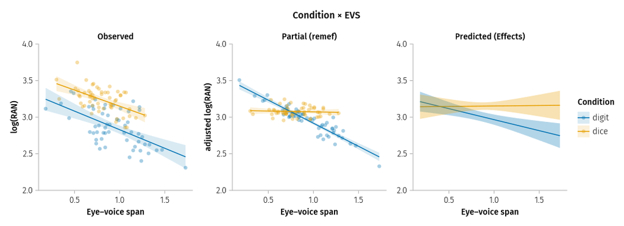

Figure 1: The eye–voice-span slope by naming Condition. Observed: both slopes negative. Partial: only `digit` retains a slope once Group and gaze are removed. Predicted: same pattern, averaged over Group (hence weaker) and with model uncertainty.

```julia
let
  grid = Dict(:evs_c => range(extrema(dat.evs_c)...; length=50), :Condition => levels(dat.Condition))
  e = effects(grid, m09; level=0.95)
  rename!(e, :lran => :yhat)
  e.evs = e.evs_c .+ mean(dat.evs)
  three_panel(; obs_df=dp, xcol=:evs, xlab="Eye–voice span", obs_y=:lran, par_y=:pf_C_evs,
    pred_df=e, color=:Condition, colorlab="Condition", title="Condition × EVS")
end
```

A larger eye–voice span goes with faster naming, and the partial panel shows this benefit is carried almost entirely by **digit** naming: once the (also reliable) `Group × EVS` term and everything involving gaze are stripped out, the `dice` slope is essentially flat. The predicted panel collapses over Group, so its `digit`/`dice` lines separate less — the interaction is real but the *marginal* prediction dilutes it.

# 6 (2) Group × EVS

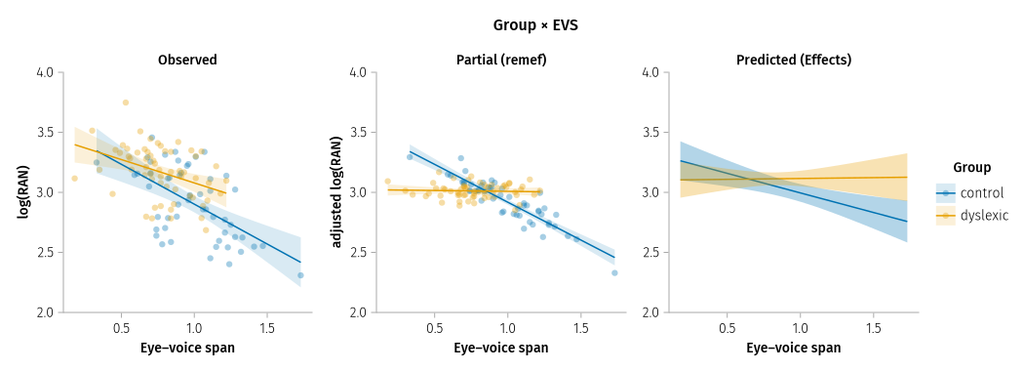

Figure 2: The eye–voice-span slope by Group. The EVS benefit is concentrated in the control children.

```julia
let
  grid = Dict(:evs_c => range(extrema(dat.evs_c)...; length=50), :Group => levels(dat.Group))
  e = effects(grid, m09; level=0.95)
  rename!(e, :lran => :yhat)
  e.evs = e.evs_c .+ mean(dat.evs)
  three_panel(; obs_df=dp, xcol=:evs, xlab="Eye–voice span", obs_y=:lran, par_y=:pf_G_evs,
    pred_df=e, color=:Group, colorlab="Group", title="Group × EVS")
end
```

The partial panel isolates the mirror-image of Figure 1: the steep negative EVS slope belongs to the **control** group, while the dyslexic slope is shallow. Substantively, a wide eye–voice span — reading ahead of the voice — pays off more for the children who are already fluent.

# 7 (3) EVS × Gaze

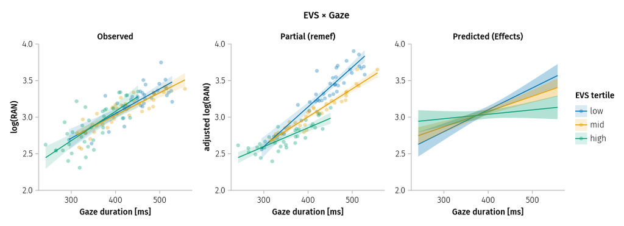

Figure 3: The gaze-duration slope at low, mid, and high eye–voice span (tertiles). Observed: the three slopes are nearly identical. Partial and Predicted: the gaze slope is steeper when the eye–voice span is short.

```julia
let
  grid = Dict(:gaze_c => range(extrema(dat.gaze_c)...; length=50),
              :evs_c => tert_med .- mean(dat.evs))
  e = effects(grid, m09; level=0.95)
  rename!(e, :lran => :yhat)
  e.gaze = e.gaze_c .+ mean(dat.gaze)
  pts = tert_med .- mean(dat.evs)
  e.evs_grp = categorical(["low", "mid", "high"][[findmin(abs.(pts .- v))[2] for v in e.evs_c]];
                          levels=["low", "mid", "high"])
  three_panel(; obs_df=dp, xcol=:gaze, xlab="Gaze duration [ms]", obs_y=:lran, par_y=:pf_evs_gz,
    pred_df=e, color=:evs_grp, colorlab="EVS tertile", title="EVS × Gaze")
end
```

This is the clearest demonstration of what the partial view buys you. In the raw data the gaze-duration slope looks the same at every eye–voice span. After removing the `Condition`, `Group`, and random-intercept contributions, a fan opens up: longer gaze durations cost more (steeper positive slope) when the reader is *not* looking far ahead. The predicted panel confirms the crossing pattern with confidence bands.

# 8 (4) Condition × Group × EVS

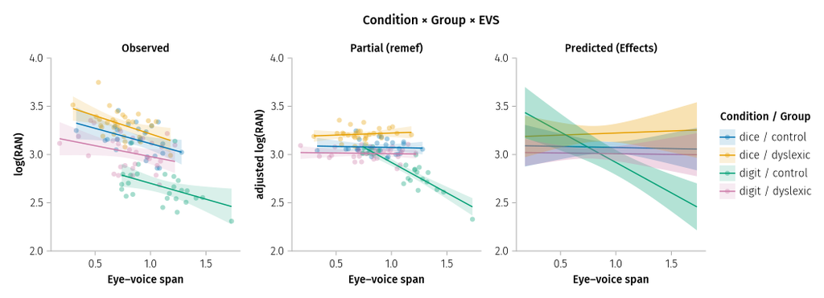

Figure 4: The three-way interaction (Figure 1 of Pan et al., 2013). The negative EVS slope is specific to the digit / control cell.

```julia
let
  grid = Dict(:evs_c => range(extrema(dat.evs_c)...; length=50),
              :Condition => levels(dat.Condition), :Group => levels(dat.Group))
  e = effects(grid, m09; level=0.95)
  rename!(e, :lran => :yhat)
  e.evs = e.evs_c .+ mean(dat.evs)
  e.cg = categorical(string.(e.Condition, " / ", e.Group))
  three_panel(; obs_df=dp, xcol=:evs, xlab="Eye–voice span", obs_y=:lran, par_y=:pf_CG_evs,
    pred_df=e, color=:cg, colorlab="Condition / Group", title="Condition × Group × EVS")
end
```

Putting `Condition` and `Group` back together: the partial panel shows three flat cells and one steeply declining one — **digit naming in control children**. The EVS benefit found in Figures 1 and 2 is not additive; it is a property of that single cell. Because the three-way grid here retains *all* the non-gaze structure, the predicted panel now agrees closely with the partial panel — nothing has been averaged away.

# 9 Takeaways

# 10 References

## 10.1 Exercises

1. **Keep the random intercept.** Recompute `pf_CG_evs` with `Dict(:Subj => ["(Intercept)"])` instead of `Dict(:Subj => String[])`. What changes in the partial panel, and which R `remef` argument does this correspond to?

**NoteSolution**

Each point moves vertically by that child’s estimated random intercept (± ~0.1 on the log scale), so the within-cell scatter grows and the cells separate a little more by their child composition. It corresponds to `remef(..., ran = list("(Intercept)"))` (keep the by-subject intercept) rather than `ran = NULL`.

2. **Effects grid resolution.** In Figure 3 the predicted lines are evaluated at three EVS values (the tertile medians). Replace them with five quantiles. Does the qualitative “fan” conclusion change? What is the cost?

**NoteSolution**

The conclusion is unchanged — the gaze slope still decreases monotonically as EVS grows. The cost is only visual: five overlapping bands are harder to read than three, and the extreme quantiles are supported by fewer observations, so their bands are wider.

3. **A non-significant term.** Build a three-panel figure for `Condition × gaze_c` (*p* ≈ .16 in `m09`). What do you expect the partial panel to look like, and why is that the right null result to show learners?

**NoteSolution**

The two partial slopes should be nearly parallel — the interaction coefficient is small and uncertain. Showing it next to the significant interactions makes the point that the partial-effect plot is not a device for manufacturing patterns: when the term is null, the plot looks null.

*This page was rendered from git revision [29e8d33](https://github.com/RePsychLing/SMLP2026/tree/29e8d33  
) using Quarto 1.10.18 and Julia 1.12.7.*

Back to top